# Assignment 4

Jagadeesh

2024-03-17

```r
DF <- read.csv("C:\\Users\\its me\\OneDrive - Kent State University\\Desktop\\Rhistory\\Pharmaceuticals.csv")
```

```r
library(tidyverse)
```

```r
library(corrplot)
library(gridExtra)
library(GGally)
library(cluster)
library(factoextra)
library(magrittr)
library(dplyr)
```

```r
head(DF)
```

```
##   Symbol                Name Market_Cap Beta PE_Ratio  ROE  ROA Asset_Turnover
## 1    ABT Abbott Laboratories      68.44 0.32     24.7 26.4 11.8            0.7
## 2    AGN      Allergan, Inc.       7.58 0.41     82.5 12.9  5.5            0.9
## 3    AHM        Amersham plc       6.30 0.46     20.7 14.9  7.8            0.9
## 4    AZN     AstraZeneca PLC      67.63 0.52     21.5 27.4 15.4            0.9
## 5    AVE             Aventis      47.16 0.32     20.1 21.8  7.5            0.6
## 6    BAY            Bayer AG      16.90 1.11     27.9  3.9  1.4            0.6
##   Leverage Rev_Growth Net_Profit_Margin Median_Recommendation Location Exchange
## 1     0.42       7.54              16.1          Moderate Buy       US     NYSE
## 2     0.60       9.16               5.5          Moderate Buy   CANADA     NYSE
## 3     0.27       7.05              11.2            Strong Buy       UK     NYSE
## 4     0.00      15.00              18.0         Moderate Sell       UK     NYSE
## 5     0.34      26.81              12.9          Moderate Buy   FRANCE     NYSE
## 6     0.00      -3.17               2.6                  Hold  GERMANY     NYSE
```

# A. Use only the numerical variables (1 to 9) to cluster the 21 firms.

Justify the various choices made in conducting the cluster analysis, such as weights for different variables, the specific clustering algorithm(s)used, the number of clusters formed, and so on.

```r
rownames(DF) <- DF$Name
View(DF)
```

```r
sum(is.na(DF))
```

```
## [1] 0
```

There are no missing values in this dataset.

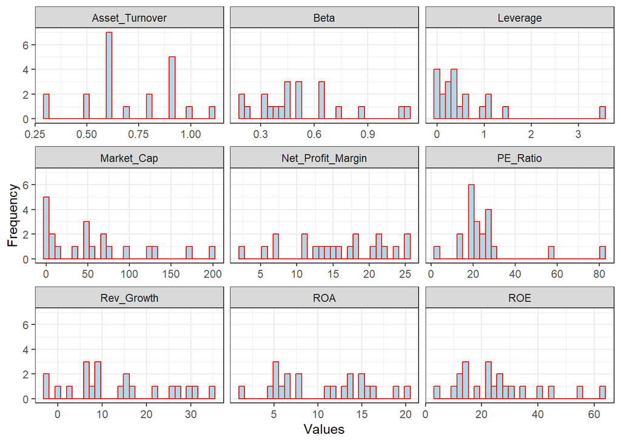

```r
DF %>%
  gather(attributes, value, 3:11) %>%
  ggplot(aes(x = value)) +
  geom_histogram(fill = 'lightblue', color = 'red') +
  facet_wrap(~attributes, scales = 'free_x') +
  labs(x="Values", y="Frequency") +
  theme_bw()
```

There seems to be an outlier in the “Leverage” attribute, and another in the “PE Ratio” attribute. These outliers could potentially impact the analysis if these variables are utilized. To streamline and enhance clarity for the equities analyst aiming to comprehend the pharmaceutical industry’s framework through fundamental financial measures, correlation analysis will be employed to identify which of the nine numerical variables are suitable for analysis.

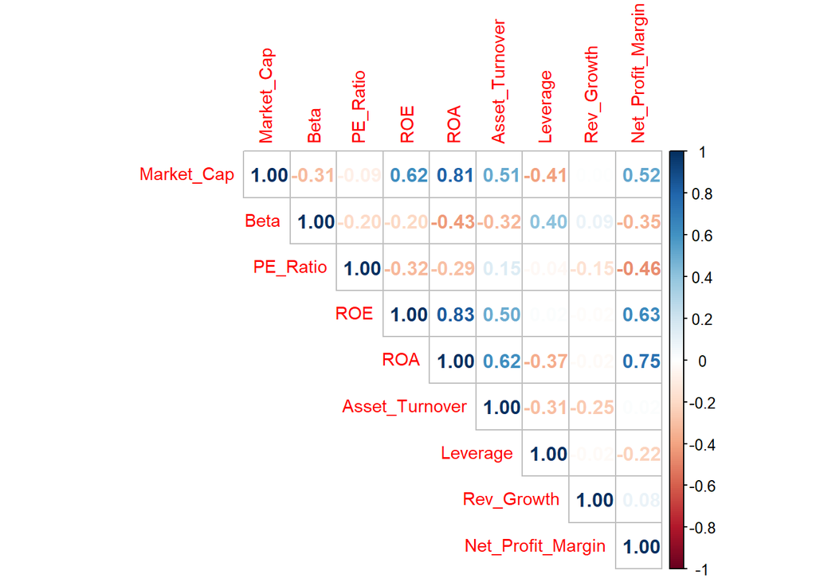

```r
corrplot(cor(DF[, c(3:11)]), type = 'upper', method = 'number', tl.cex = 0.9)
```

The correlation between Leverage and PE Ratio seems weak, suggesting that the outliers they harbor might not significantly influence the analysis. However, there is a robust linear correlation between Net Profit Margin and ROA. Therefore, these two variables, Net Profit Margin and ROA, will be the focus of the analysis. The objective of this assignment is to apply k-Means for clustering, hence k-Means will be the chosen method for this analysis.

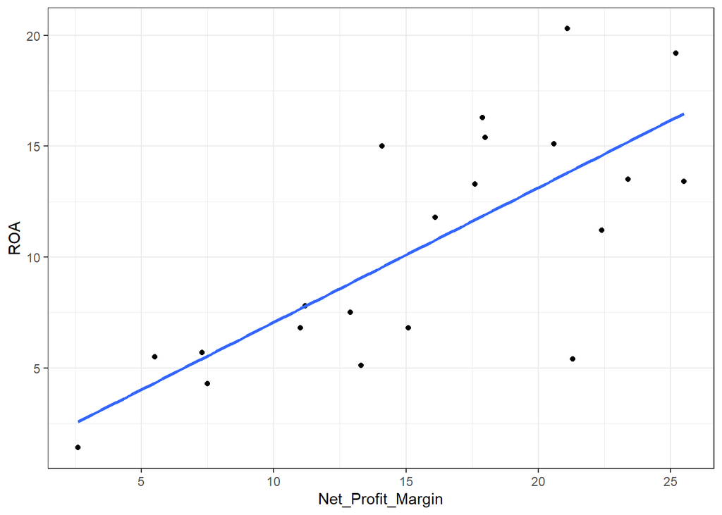

```r
ggplot(DF, aes(x = Net_Profit_Margin, y = ROA)) +
  geom_point() +
  geom_smooth(method = 'lm', se = FALSE) +
  theme_bw()
```

# a. Use only the numerical variables (1 to 9) to cluster the 21 firms.

```r
DF2 <- DF[, -c(12, 13, 14)]
head(DF2)
```

```
##                     Symbol                Name Market_Cap Beta PE_Ratio  ROE
## Abbott Laboratories    ABT Abbott Laboratories      68.44 0.32     24.7 26.4
## Allergan, Inc.         AGN      Allergan, Inc.       7.58 0.41     82.5 12.9
## Amersham plc           AHM        Amersham plc       6.30 0.46     20.7 14.9
## AstraZeneca PLC        AZN     AstraZeneca PLC      67.63 0.52     21.5 27.4
## Aventis                AVE             Aventis      47.16 0.32     20.1 21.8
## Bayer AG               BAY            Bayer AG      16.90 1.11     27.9  3.9
##                      ROA Asset_Turnover Leverage Rev_Growth Net_Profit_Margin
## Abbott Laboratories 11.8            0.7     0.42       7.54              16.1
## Allergan, Inc.       5.5            0.9     0.60       9.16               5.5
## Amersham plc         7.8            0.9     0.27       7.05              11.2
## AstraZeneca PLC     15.4            0.9     0.00      15.00              18.0
## Aventis              7.5            0.6     0.34      26.81              12.9
## Bayer AG             1.4            0.6     0.00      -3.17               2.6
```

Non-Numerical columns are removed (Median_Recommendation, Location, and Exchange).

```r
str(DF2)
```

```
## 'data.frame':    21 obs. of  11 variables:
##  $ Symbol           : chr  "ABT" "AGN" "AHM" "AZN" ...
##  $ Name             : chr  "Abbott Laboratories" "Allergan, Inc." "Amersham plc" "AstraZeneca PLC" ...
##  $ Market_Cap       : num  68.44 7.58 6.3 67.63 47.16 ...
##  $ Beta             : num  0.32 0.41 0.46 0.52 0.32 1.11 0.5 0.85 1.08 0.18 ...
##  $ PE_Ratio         : num  24.7 82.5 20.7 21.5 20.1 27.9 13.9 26 3.6 27.9 ...
##  $ ROE              : num  26.4 12.9 14.9 27.4 21.8 3.9 34.8 24.1 15.1 31 ...
##  $ ROA              : num  11.8 5.5 7.8 15.4 7.5 1.4 15.1 4.3 5.1 13.5 ...
##  $ Asset_Turnover   : num  0.7 0.9 0.9 0.9 0.6 0.6 0.9 0.6 0.3 0.6 ...
##  $ Leverage         : num  0.42 0.6 0.27 0 0.34 0 0.57 3.51 1.07 0.53 ...
##  $ Rev_Growth       : num  7.54 9.16 7.05 15 26.81 ...
##  $ Net_Profit_Margin: num  16.1 5.5 11.2 18 12.9 2.6 20.6 7.5 13.3 23.4 ...
```

```r
DF2 <- DF2[, -c(1,2)]
head(DF2)
```

```
##                     Market_Cap Beta PE_Ratio  ROE  ROA Asset_Turnover Leverage
## Abbott Laboratories      68.44 0.32     24.7 26.4 11.8            0.7     0.42
## Allergan, Inc.            7.58 0.41     82.5 12.9  5.5            0.9     0.60
## Amersham plc              6.30 0.46     20.7 14.9  7.8            0.9     0.27
## AstraZeneca PLC          67.63 0.52     21.5 27.4 15.4            0.9     0.00
## Aventis                  47.16 0.32     20.1 21.8  7.5            0.6     0.34
## Bayer AG                 16.90 1.11     27.9  3.9  1.4            0.6     0.00
##                     Rev_Growth Net_Profit_Margin
## Abbott Laboratories       7.54              16.1
## Allergan, Inc.            9.16               5.5
## Amersham plc              7.05              11.2
## AstraZeneca PLC          15.00              18.0
## Aventis                  26.81              12.9
## Bayer AG                 -3.17               2.6
```

The Name and Symbol columns have been excluded to facilitate scaling of the dataset.

```r
summary(DF2)
```

```
##    Market_Cap          Beta           PE_Ratio          ROE
##  Min.   :  0.41   Min.   :0.1800   Min.   : 3.60   Min.   : 3.9
##  1st Qu.:  6.30   1st Qu.:0.3500   1st Qu.:18.90   1st Qu.:14.9
##  Median : 48.19   Median :0.4600   Median :21.50   Median :22.6
##  Mean   : 57.65   Mean   :0.5257   Mean   :25.46   Mean   :25.8
##  3rd Qu.: 73.84   3rd Qu.:0.6500   3rd Qu.:27.90   3rd Qu.:31.0
##  Max.   :199.47   Max.   :1.1100   Max.   :82.50   Max.   :62.9
##       ROA        Asset_Turnover    Leverage        Rev_Growth
##  Min.   : 1.40   Min.   :0.3    Min.   :0.0000   Min.   :-3.17
##  1st Qu.: 5.70   1st Qu.:0.6    1st Qu.:0.1600   1st Qu.: 6.38
##  Median :11.20   Median :0.6    Median :0.3400   Median : 9.37
##  Mean   :10.51   Mean   :0.7    Mean   :0.5857   Mean   :13.37
##  3rd Qu.:15.00   3rd Qu.:0.9    3rd Qu.:0.6000   3rd Qu.:21.87
##  Max.   :20.30   Max.   :1.1    Max.   :3.5100   Max.   :34.21
##  Net_Profit_Margin
##  Min.   : 2.6
##  1st Qu.:11.2
##  Median :16.1
##  Mean   :15.7
##  3rd Qu.:21.1
##  Max.   :25.5
```

```r
DF2 <- scale(DF2)
head(DF2)
```

```
##                     Market_Cap        Beta    PE_Ratio         ROE        ROA
## Abbott Laboratories  0.1840960 -0.80125356 -0.04671323  0.04009035  0.2416121
## Allergan, Inc.      -0.8544181 -0.45070513  3.49706911 -0.85483986 -0.9422871
## Amersham plc        -0.8762600 -0.25595600 -0.29195768 -0.72225761 -0.5100700
## AstraZeneca PLC      0.1702742 -0.02225704 -0.24290879  0.10638147  0.9181259
## Aventis             -0.1790256 -0.80125356 -0.32874435 -0.26484883 -0.5664461
## Bayer AG            -0.6953818  2.27578267  0.14948233 -1.45146000 -1.7127612
##                     Asset_Turnover   Leverage Rev_Growth Net_Profit_Margin
## Abbott Laboratories      0.0000000 -0.2120979 -0.5277675        0.06168225
## Allergan, Inc.           0.9225312  0.0182843 -0.3811391       -1.55366706
## Amersham plc             0.9225312 -0.4040831 -0.5721181       -0.68503583
## AstraZeneca PLC          0.9225312 -0.7496565  0.1474473        0.35122600
## Aventis                 -0.4612656 -0.3144900  1.2163867       -0.42597037
## Bayer AG                -0.4612656 -0.7496565 -1.4971443       -1.99560225
```

```r
DF_ROA_NPM <- DF2[, c(5,9)]
summary(DF_ROA_NPM) # Clustering the firms based on their Net_Profit_Margin and ROA due to their strong correlation
```

```
##       ROA          Net_Profit_Margin
##  Min.   :-1.7128   Min.   :-1.99560
##  1st Qu.:-0.9047   1st Qu.:-0.68504
##  Median : 0.1289   Median : 0.06168
##  Mean   : 0.0000   Mean   : 0.00000
##  3rd Qu.: 0.8430   3rd Qu.: 0.82364
##  Max.   : 1.8389   Max.   : 1.49416
```

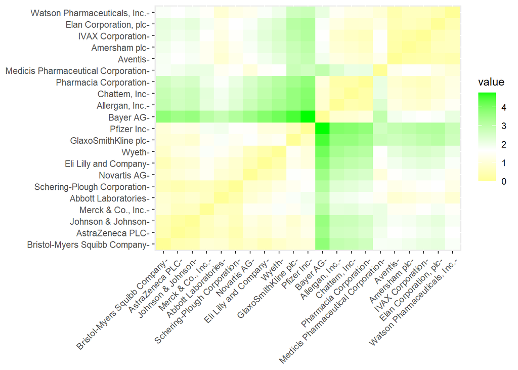

```r
distance <- get_dist(DF_ROA_NPM) # Using Net Profit Margin and ROA for analysis
fviz_dist(distance, gradient = list(low = "yellow", mid = "white", high = "green"))
```

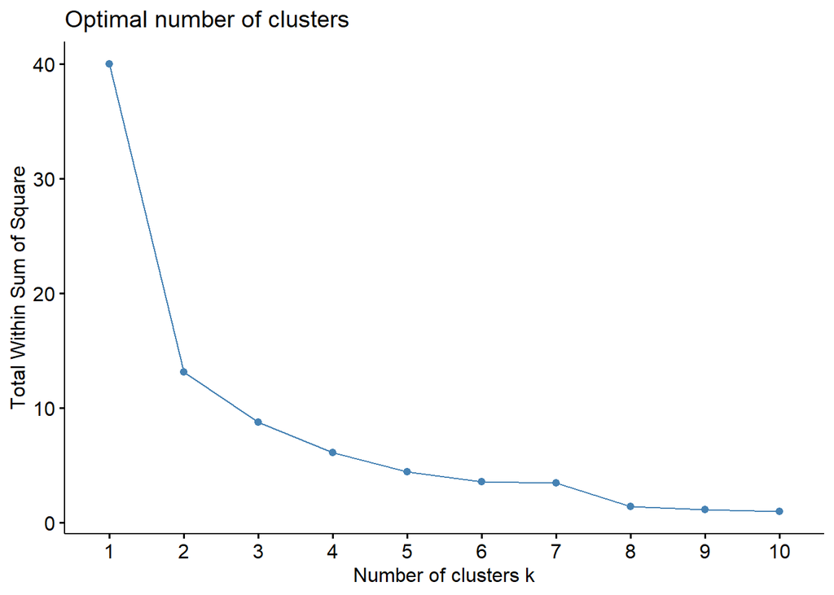

```r
fviz_nbclust(DF_ROA_NPM, kmeans, method = "wss") # Elbow Graph
```

The optimal number of clusters is 2 via the Elbow Graph method.

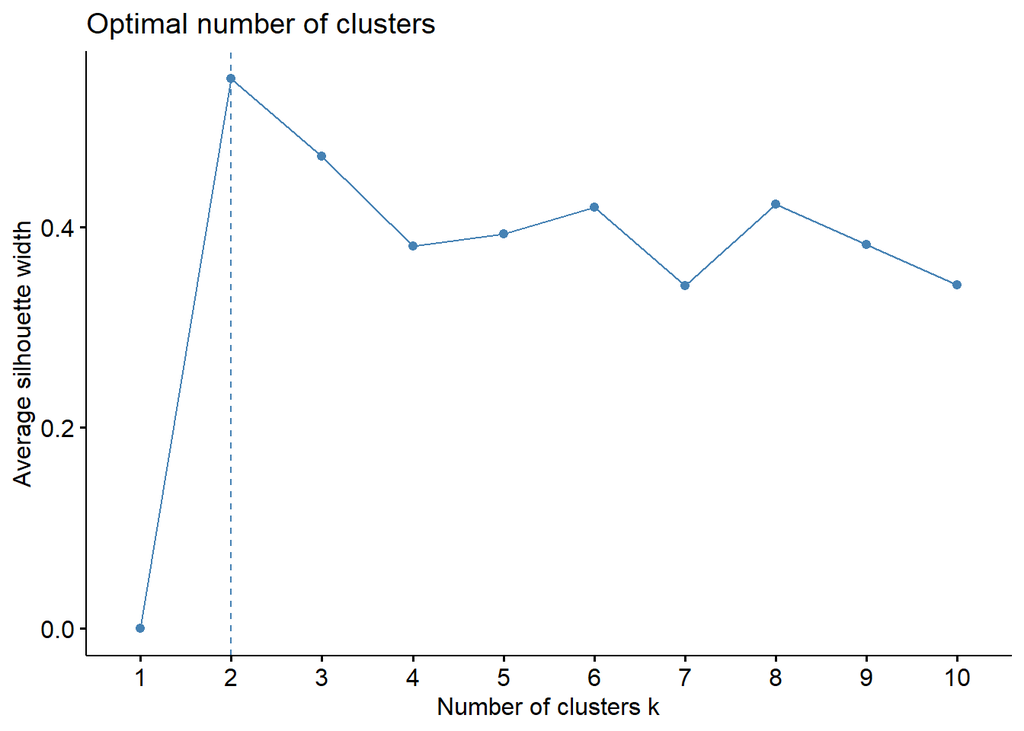

```r
fviz_nbclust(DF_ROA_NPM, kmeans, method = "silhouette") # Silhouette Graph
```

The optimal number of clusters is 2 via the Silhouette method.

```r
set.seed(234)

k2 <- kmeans(DF_ROA_NPM, centers = 2, nstart = 25)
print(k2)
```

```
## K-means clustering with 2 clusters of sizes 11, 10
##
## Cluster means:
##          ROA Net_Profit_Margin
## 1  0.8344159         0.6823310
## 2 -0.9178575        -0.7505641
##
## Clustering vector:
##                Abbott Laboratories                     Allergan, Inc.
##                                  1                                  2
##                       Amersham plc                    AstraZeneca PLC
##                                  2                                  1
##                            Aventis                           Bayer AG
##                                  2                                  2
##       Bristol-Myers Squibb Company                       Chattem, Inc
##                                  1                                  2
##              Elan Corporation, plc              Eli Lilly and Company
##                                  2                                  1
##                GlaxoSmithKline plc                   IVAX Corporation
##                                  1                                  2
##                  Johnson & Johnson Medicis Pharmaceutical Corporation
##                                  1                                  2
##                  Merck & Co., Inc.                        Novartis AG
##                                  1                                  1
##                         Pfizer Inc              Pharmacia Corporation
##                                  1                                  2
##        Schering-Plough Corporation       Watson Pharmaceuticals, Inc.
##                                  1                                  2
##                              Wyeth
##                                  1
##
## Within cluster sum of squares by cluster:
## [1] 6.07548 7.08635
##  (between_SS / total_SS =  67.1 %)
##
## Available components:
##
## [1] "cluster"      "centers"      "totss"        "withinss"     "tot.withinss"
## [6] "betweenss"    "size"         "iter"         "ifault"
```

```r
k2$centers
```

```
##          ROA Net_Profit_Margin
## 1  0.8344159         0.6823310
## 2 -0.9178575        -0.7505641
```

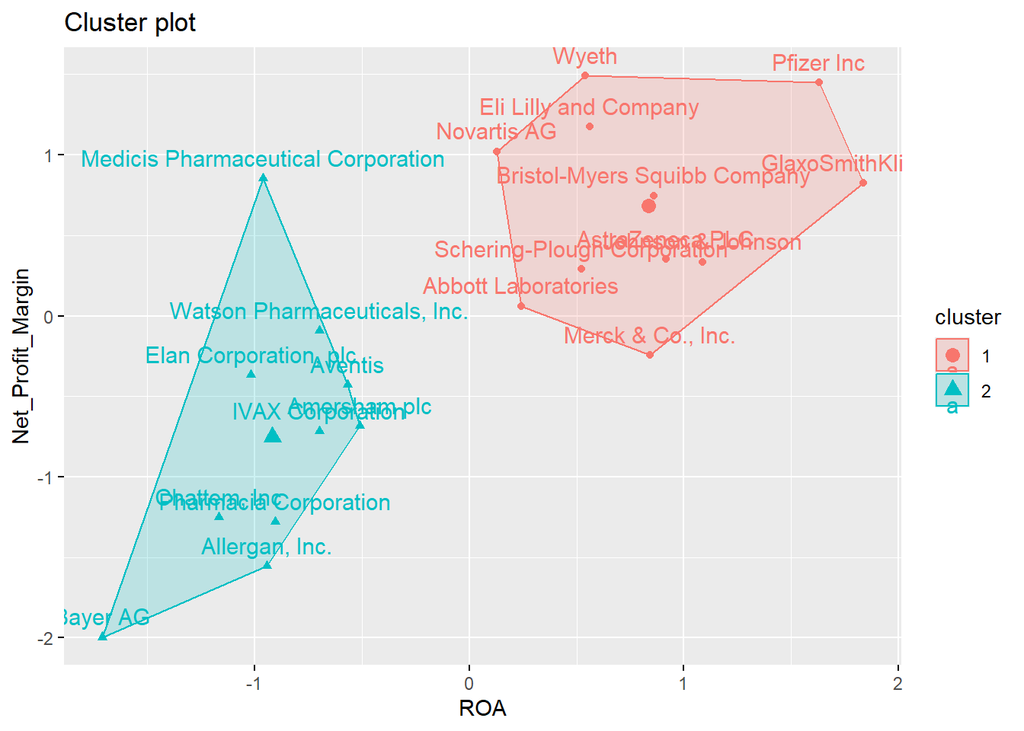

```r
fviz_cluster(k2, data = DF_ROA_NPM)
```

```r
fit_data <- kmeans(DF_ROA_NPM, 2)
aggregate(DF_ROA_NPM, by = list(fit_data$cluster), FUN = mean)
```

```
##   Group.1        ROA Net_Profit_Margin
## 1       1  0.8344159         0.6823310
## 2       2 -0.9178575        -0.7505641
```

```r
norm_data <- as.data.frame(DF_ROA_NPM, fit_data$cluster)
rownames(norm_data) <- DF$Symbol
norm_data
```

```
##             ROA Net_Profit_Margin
## ABT   0.2416121        0.06168225
## AGN  -0.9422871       -1.55366706
## AHM  -0.5100700       -0.68503583
## AZN   0.9181259        0.35122600
## AVE  -0.5664461       -0.42597037
## BAY  -1.7127612       -1.99560225
## BMY   0.8617498        0.74744375
## CHTT -1.1677918       -1.24888417
## ELN  -1.0174553       -0.36501379
## LLY   0.5610770        1.17413980
## GSK   1.8389364        0.82363947
## IVX  -0.6979905       -0.71551412
## JNJ   1.0872544        0.33598685
## MRX  -0.9610792        0.85411776
## MRK   0.8429577       -0.24310064
## NVS   0.1288598        1.02174835
## PFE   1.6322239        1.44844440
## PHA  -0.9047030       -1.27936246
## SGP   0.5234929        0.29026942
## WPI  -0.6979905       -0.09070919
## WYE   0.5422849        1.49416183
```

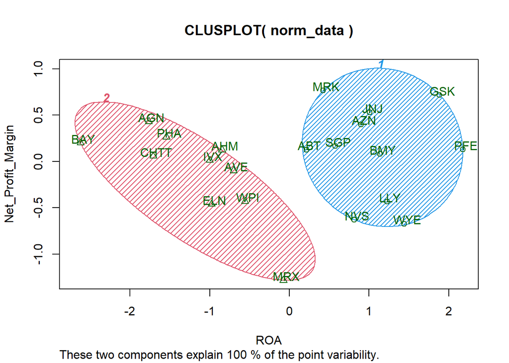

```r
clusplot(norm_data, fit_data$cluster, color = TRUE, shade = TRUE, labels = 2, lines = 0, xlab = "ROA", ylab = "Net_Profit_Margin")
```

# B. Interpret the clusters with respect to the numerical variables used in forming the clusters

Cluster 1 (BLUE) boasts an average ROA of 0.83, while Cluster 2 (RED) shows an average ROA of -0.91. In essence, Cluster 1 exhibits a superior average ROA compared to Cluster 2.

Cluster 1 (BLUE) demonstrates an average Net Profit Margin of 0.68, whereas Cluster 2 (RED) showcases an average Net Profit Margin of -0.75. This implies that Cluster 1 maintains a higher average Net Profit Margin than Cluster 2.

To sum up: Cluster 1 (BLUE) displays higher averages in both Return on Assets (ROA) and Net Profit Margin. Cluster 2 (RED) presents lower averages in both Return on Assets (ROA) and Net Profit Margin.

# C. Is there a pattern in the clusters with respect to the non-numerical variables (10 to 12)?

```r
dd <- cbind(DF, cluster = k2$cluster)
head(dd)
```

```
##                     Symbol                Name Market_Cap Beta PE_Ratio  ROE
## Abbott Laboratories    ABT Abbott Laboratories      68.44 0.32     24.7 26.4
## Allergan, Inc.         AGN      Allergan, Inc.       7.58 0.41     82.5 12.9
## Amersham plc           AHM        Amersham plc       6.30 0.46     20.7 14.9
## AstraZeneca PLC        AZN     AstraZeneca PLC      67.63 0.52     21.5 27.4
## Aventis                AVE             Aventis      47.16 0.32     20.1 21.8
## Bayer AG               BAY            Bayer AG      16.90 1.11     27.9  3.9
##                      ROA Asset_Turnover Leverage Rev_Growth Net_Profit_Margin
## Abbott Laboratories 11.8            0.7     0.42       7.54              16.1
## Allergan, Inc.       5.5            0.9     0.60       9.16               5.5
## Amersham plc         7.8            0.9     0.27       7.05              11.2
## AstraZeneca PLC     15.4            0.9     0.00      15.00              18.0
## Aventis              7.5            0.6     0.34      26.81              12.9
## Bayer AG             1.4            0.6     0.00      -3.17               2.6
##                     Median_Recommendation Location Exchange cluster
## Abbott Laboratories          Moderate Buy       US     NYSE       1
## Allergan, Inc.               Moderate Buy   CANADA     NYSE       2
## Amersham plc                   Strong Buy       UK     NYSE       2
## AstraZeneca PLC             Moderate Sell       UK     NYSE       1
## Aventis                      Moderate Buy   FRANCE     NYSE       2
## Bayer AG                             Hold  GERMANY     NYSE       2
```

# D. Provide an appropriate name for each cluster using any or all of the variables in the dataset.

Cluster 1, identified by its higher average ROA and Net Profit Margin, tends to receive “Hold” and “Moderate Buy” recommendations for stock purchases and investments. The majority of its firms are located in the US, and all are listed exclusively with the NYSE stock exchange.

Cluster 1 can be described as “Risk-Averse and Profitable,”

while Cluster 2 can be labeled as “Risk-Prone and Less Profitable.”